# Research project

Sofiia Folvarochna, Anastasiia Beheni, Olesia Omelchuk

# Analyzing Udemy courses

## Project setting

The link for database: https://www.kaggle.com/datasets/mariahalshiekh/udemy-course-academy-teaching

## Preparing and cleaning the data

```r
# some useful libraries
library(tidyr)
library(dplyr)
```

```r
library(ggplot2)
library(MASS)
#color palette #F5B4AF - pink, #B7D079 - green, #79D8DB - blue, #DCB7F9 - purple
```

There were a lot of features provided in the original dataset. Still, the title of the course and names of teachers, for example, wasn’t that important for our analysis, so we took into account only valuable data:

- course rating
- number of course reviews
- total hours to pass the course
- number of lectures
- course level
- price
- number of enrollments

We also changed the string representation of course level to integer numbers as it is more convenient to work with.

```r
data <- read.csv("udemy_dataset.csv")
data <- data[, c(5,6,7,8,9,10,12)]
data$course_level[data$course_level == "Beginner"] <- 0
data$course_level[data$course_level == "Intermediate"] <- 1
data$course_level[data$course_level == "Expert"] <- 2
data$course_level[data$course_level == "All Levels"] <- 3
data$course_level <- as.integer(data$course_level)
head(data)
```

|  | course_rating | coures_reviews | course_totalHourse | course_lectures | course_level | price | course_enrollmenters |
| --- | --- | --- | --- | --- | --- | --- | --- |
| 1 | 4.5 | 22271 | 77.5 | 380 | 3 | 139.99 | 100434 |
| 2 | 4.7 | 16401 | 4.0 | 49 | 0 | 19.99 | 61407 |
| 3 | 4.6 | 12249 | 6.0 | 66 | 1 | 39.99 | 64388 |
| 4 | 4.3 | 9658 | 17.0 | 62 | 3 | 19.99 | 54357 |
| 5 | 4.7 | 9579 | 4.5 | 100 | 0 | 179.99 | 38388 |
| 6 | 4.4 | 8450 | 77.0 | 63 | 0 | 174.99 | 36029 |

## Analyzing the data

### Distributions of main features

To better understand the data we were working with, we decided to plot the distributions of the features that we were planning to use in hypotheses testing.

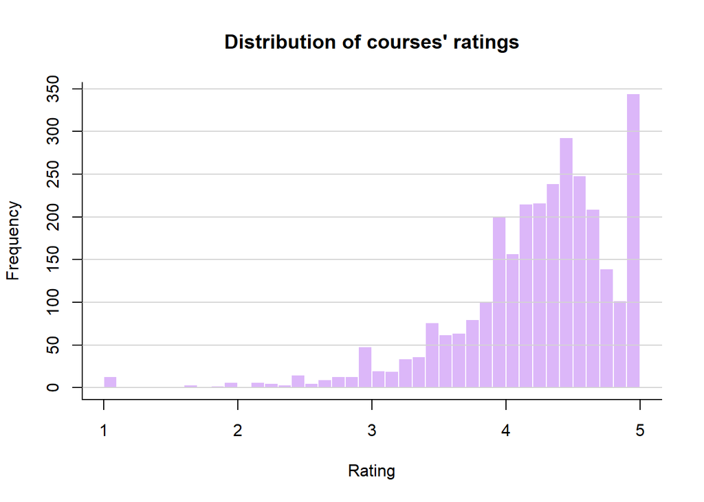

```r
hist(data$course_rating, col = "#DCB7F9", xlab="Rating", border = "white", main="Distribution of courses' ratings", breaks = seq(1,5,0.1))
box(bty="l")
grid(nx=NA,ny=NULL,lty=1,lwd=1,col="lightgrey")
```

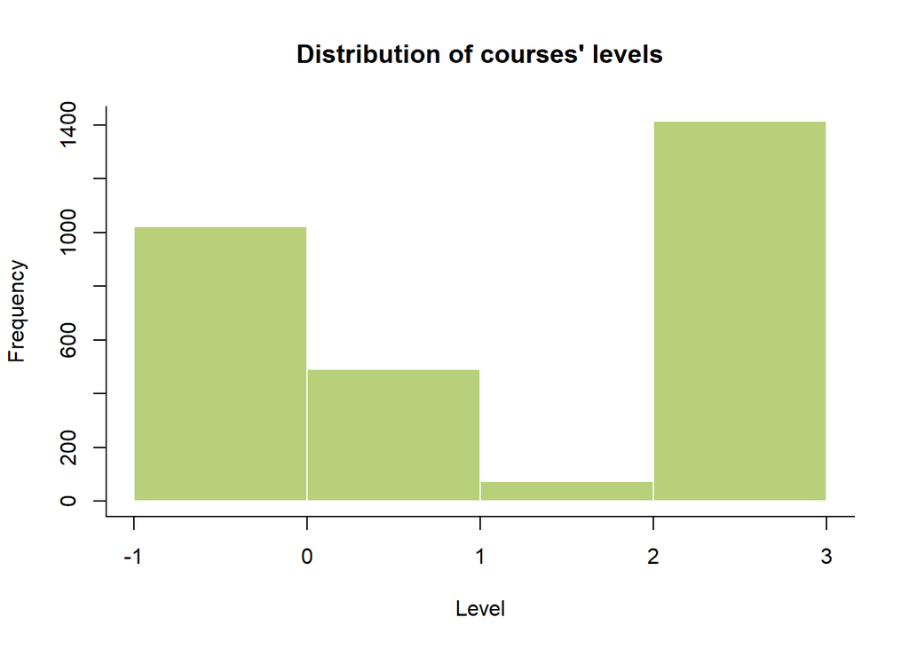

```r
hist(data$course_level, col = "#B7D079", xlab="Level", border = "white", main="Distribution of courses' levels", breaks = seq(-1,3))
box(bty="l")
```

While plotting the number of enrollments, we run into a problem that our graph isn’t representative and doesn’t give that much information as there is a huge span in this feature (the min value is 0, max - 154 706, and mean 1733). That’s why we decided to find the percentiles and plot only 90% of the data to see how it behaves. (**in hypotheses testing, we used the complete data**)

```r
quantile(data$course_enrollmenters, c(.9, .95, .99))
```

```
##      90%      95%      99%
##  3481.40  7392.30 28520.12
```

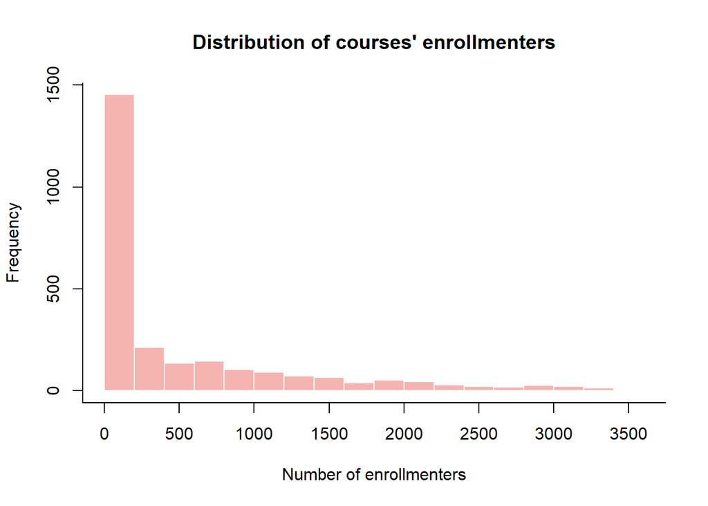

```r
data_enrollments <- data[data$course_enrollmenters < 3482 & data$course_enrollmenters != 0 ,]
hist(data_enrollments$course_enrollmenters, col = "#F5B4AF", xlab="Number of enrollmenters", border = "white", main="Distribution of courses' enrollmenters")
box(bty="l")
```

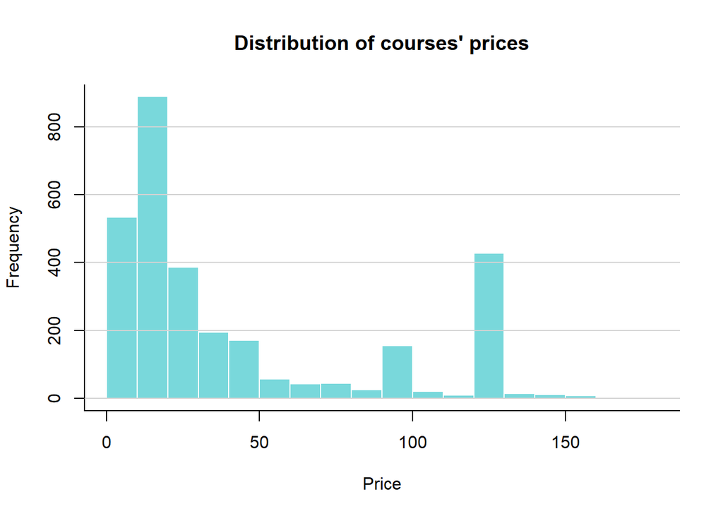

```r
hist(data$price, col = "#79D8DB", xlab="Price", border = "white", main="Distribution of courses' prices")
box(bty="l")
grid(nx=NA,ny=NULL,lty=1,lwd=1,col="lightgrey")
```

### Checking how one feature influences other ones

As we wanted to check the dependence of some features of the set of courses, we decided to plot their distributions while being split into some categories.

To check how different features influence the *course rating* we split our data into two categories:

- high: rating >= 4
- low: rating < 4

```r
data$high <- data$course_rating >= 4
summary(data)
```

```
##  course_rating  coures_reviews    course_totalHourse course_lectures
##  Min.   :1.00   Min.   :    1.0   Min.   :  1.000    Min.   :  5.00
##  1st Qu.:4.00   1st Qu.:    4.0   1st Qu.:  1.500    1st Qu.: 13.00
##  Median :4.40   Median :   11.0   Median :  3.000    Median : 22.00
##  Mean   :4.27   Mean   :  140.7   Mean   :  7.363    Mean   : 39.05
##  3rd Qu.:4.70   3rd Qu.:   43.0   3rd Qu.:  6.000    3rd Qu.: 43.00
##  Max.   :5.00   Max.   :22271.0   Max.   :190.000    Max.   :632.00
##   course_level       price        course_enrollmenters    high
##  Min.   :0.000   Min.   :  0.00   Min.   :     0       Mode :logical
##  1st Qu.:0.000   1st Qu.: 19.99   1st Qu.:    23       FALSE:636
##  Median :1.000   Median : 24.99   Median :   153       TRUE :2363
##  Mean   :1.626   Mean   : 45.55   Mean   :  1733
##  3rd Qu.:3.000   3rd Qu.: 69.99   3rd Qu.:  1099
##  Max.   :3.000   Max.   :179.99   Max.   :154706
```

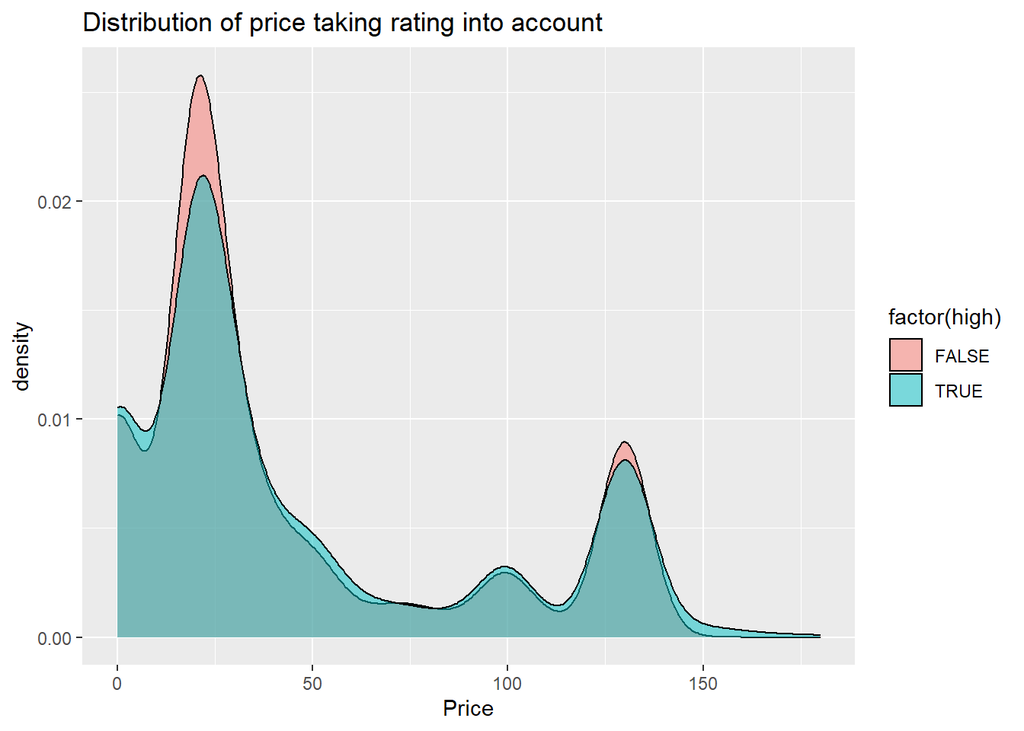

```r
ggplot(data, aes(x=price,fill=factor(high)))+geom_density(alpha=0.5)+
 xlab(label = "Price")+
 ggtitle("Distribution of price taking rating into account")
```

!*for number of reviews, enrollments and course total hours we used the same trick with percentiles as before*!

```r
quantile(data$coures_reviews, c(.9, .95, .99))
```

```
##     90%     95%     99%
##  177.20  353.20 3353.32
```

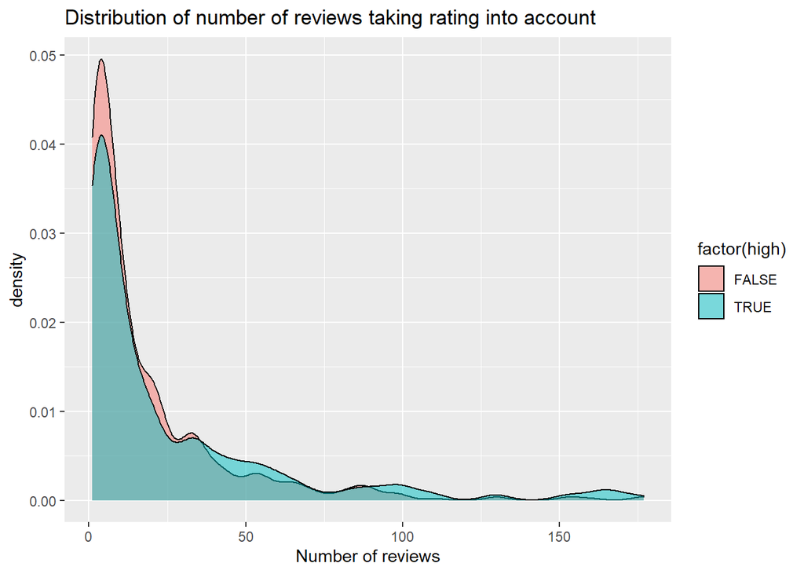

```r
data_reviews <- data[data$coures_reviews < 178, ]
ggplot(data_reviews, aes(x=coures_reviews,fill=factor(high)))+geom_density(alpha=0.5)+
 xlab(label = "Number of reviews")+
 ggtitle("Distribution of number of reviews taking rating into account")
```

```r
quantile(data$course_enrollmenters, c(.9, .95, .99))
```

```
##      90%      95%      99%
##  3481.40  7392.30 28520.12
```

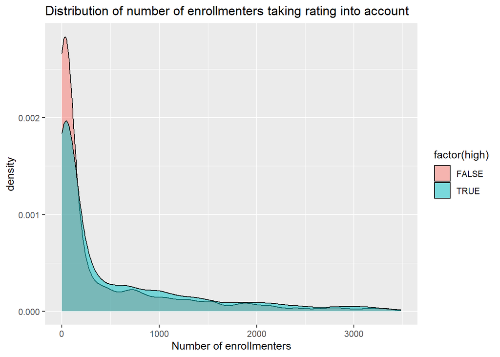

```r
data_enrollments <- data[data$course_enrollmenters < 3482, ]
ggplot(data_enrollments, aes(x=course_enrollmenters,fill=factor(high)))+geom_density(alpha=0.5)+
 xlab(label = "Number of enrollmenters")+
 ggtitle("Distribution of number of enrollmenters taking rating into account")
```

```r
quantile(data$course_totalHourse, c(.9, .95, .99))
```

```
##  90%  95%  99%
## 27.1 37.0 44.0
```

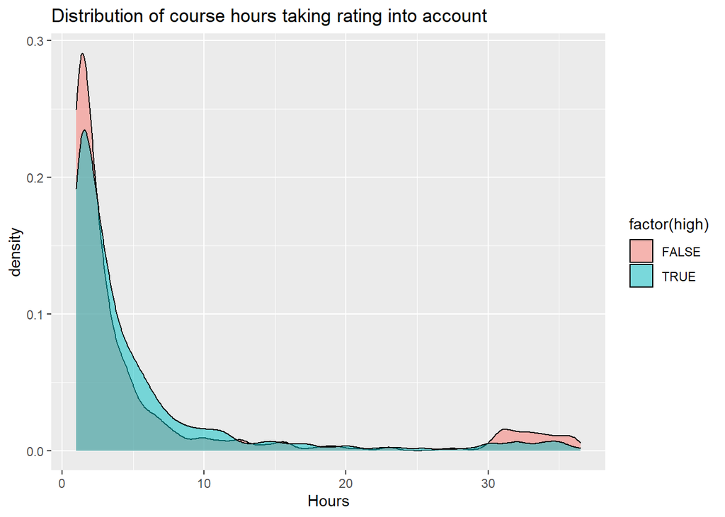

```r
data_hours <- data[data$course_totalHourse < 37, ]
ggplot(data_hours, aes(x=course_totalHourse,fill=factor(high)))+geom_density(alpha=0.5)+
 xlab(label = "Hours")+
 ggtitle("Distribution of course hours taking rating into account")
```

The distributions turned out to be pretty similar with some quite expected differences (for example, that courses with higher ratings have a bigger number of enrollments); that’s why we decided to split our data based on other factors, such as *course level* and *number of enrollments*.

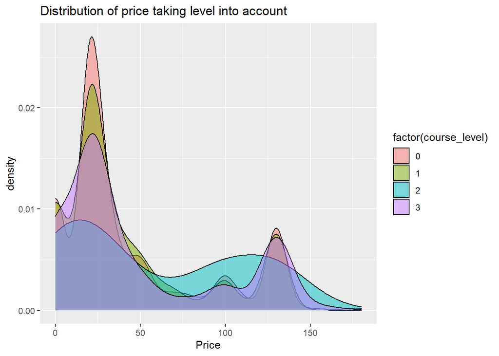

```r
ggplot(data, aes(x=price,fill=factor(course_level)))+geom_density(alpha=0.5)+
 xlab(label = "Price")+
 ggtitle("Distribution of price taking level into account")
```

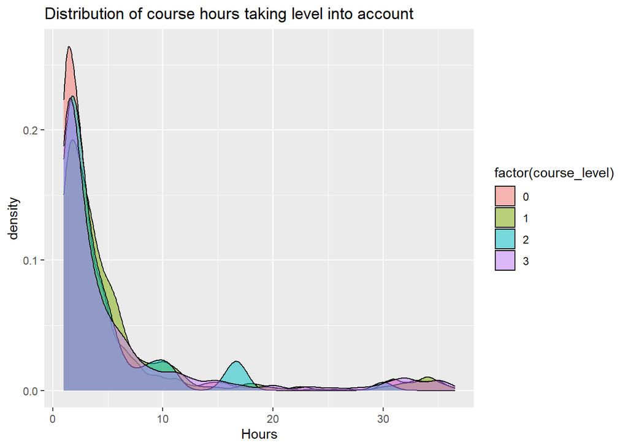

```r
data_hours <- data[data$course_totalHourse < 37, ]
ggplot(data_hours, aes(x=course_totalHourse,fill=factor(course_level)))+geom_density(alpha=0.5)+
 xlab(label = "Hours")+
 ggtitle("Distribution of course hours taking level into account")
```

```r
quantile(data$course_enrollmenters)
```

```
##     0%    25%    50%    75%   100%
##      0     23    153   1099 154706
```

```r
# 0 - 870
# 871 - 1740
# 1741 - 2610
# 2611 - 3480


data_enrollments <- data[data$course_enrollmenters < 3482, ]

# quantile(data_enrollments$course_enrollmenters, c(.9, .95, .99))
max(data_enrollments$course_enrollmenters)
```

```
## [1] 3480
```

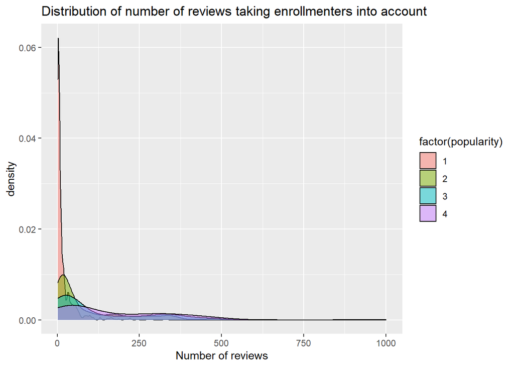

```r
data_enrollments <- data_enrollments%>%
  mutate(popularity = case_when((data_enrollments$course_enrollmenters <= 870) ~ 1,
                                (data_enrollments$course_enrollmenters > 870  & data_enrollments$course_enrollmenters <= 1740) ~ 2,
                                (data_enrollments$course_enrollmenters > 1740  & data_enrollments$course_enrollmenters <= 2610) ~ 3,
                                (data_enrollments$course_enrollmenters > 2610) ~ 4))

ggplot(data_enrollments, aes(x=coures_reviews,fill=factor(popularity)))+geom_density(alpha=0.5)+
 xlab(label = "Number of reviews")+
 ggtitle("Distribution of number of reviews taking enrollmenters into account")
```

```r
correlation <- cor(data)
print(correlation[, "coures_reviews"])
```

```
##        course_rating       coures_reviews   course_totalHourse
##           0.05482964           1.00000000           0.13391954
##      course_lectures         course_level                price
##           0.23692037           0.01771252           0.15025519
## course_enrollmenters                 high
##           0.68463040           0.07058943
```

```r
print(correlation[, "course_rating"])
```

```
##        course_rating       coures_reviews   course_totalHourse
##          1.000000000          0.054829638         -0.071730299
##      course_lectures         course_level                price
##          0.078158105         -0.035590292          0.008679106
## course_enrollmenters                 high
##          0.006959290          0.770849028
```

```r
print(correlation[, "course_level"])
```

```
##        course_rating       coures_reviews   course_totalHourse
##          -0.03559029           0.01771252           0.02707462
##      course_lectures         course_level                price
##           0.07602624           1.00000000           0.04762175
## course_enrollmenters                 high
##           0.02814496          -0.03934349
```

As we can see on previous graphs and correlation results, it seems like there isn’t almost any dependency between the features (course enrollments and the number of reviews have the highest correlation, but it is pretty obvious and not interesting to analyze). To check this assumption we decided to test some hypotheses about independence of the features.

## Testing hypotheses

In all following pairs of hypotheses we are going to test the independence of two characteristics that’s why we use **Chi-squared test for independence**.

Here is the corresponding test statistic:
$$\chi^2 =
\sum_{i=1}^R\sum_{j=1}^C\frac{(o_{ij}-e_{ij})^2}{e_{ij}}$$
where $o_{ij}$ is the observed value in the i-th row and j-th column, and $e_{ij}$ is the expected value.

Then the calculated value of the statistic is compared to the corresponding value of $\chi^2_{(R-1)(C-1)}$ with $(R-1)(C-1)$ degrees of freedom and for a certain confidence level.

$H_0$ - there is no dependency between the **course level** and **course enrollments**

$H_1$ - there is a dependency between those metrics

```r
# creating the dataframe
number_of_enrollmenters <- unique(data$course_enrollmenters)
l.0 <- c()
l.1 <- c()
l.2 <- c()
l.3 <- c()

for (i in number_of_enrollmenters){
  l.0 <- c(l.0, nrow(data[data$course_level == 0 & data$course_enrollmenters == i,]))
  l.1 <- c(l.1, nrow(data[data$course_level == 1 & data$course_enrollmenters == i,]))
  l.2 <- c(l.2, nrow(data[data$course_level == 2 & data$course_enrollmenters == i,]))
  l.3 <- c(l.3, nrow(data[data$course_level == 3 & data$course_enrollmenters == i,]))
}
df <- data.frame(l.0,l.1,l.2,l.3, row.names = number_of_enrollmenters)
df
```

|  | l.0 | l.1 | l.2 | l.3 |
| --- | --- | --- | --- | --- |
| 100434 | 0 | 0 | 0 | 1 |
| 61407 | 1 | 0 | 0 | 0 |
| 64388 | 0 | 1 | 0 | 0 |
| 54357 | 0 | 0 | 0 | 1 |
| 38388 | 1 | 0 | 0 | 0 |
| 36029 | 1 | 0 | 0 | 0 |
| 34961 | 0 | 0 | 0 | 1 |
| 43634 | 0 | 0 | 0 | 1 |
| 50793 | 0 | 0 | 0 | 1 |
| 54024 | 1 | 0 | 0 | 0 |

[output cut: 1321 more lines]

```r
# running the test
chisq.test(df)
```

```
##
##  Pearson's Chi-squared test
##
## data:  df
## X-squared = 4025.4, df = 3990, p-value = 0.3438
```

$H_0$ - there is no dependency between the **course price** and **course rating**

$H_1$ - there is a dependency between those metrics

```r
# creating the dataframe
prices <- unique(data$price)
r.2 <- c()
r.3 <- c()
r.4 <- c()
r.5 <- c()

for (i in prices){
  r.2 <- c(r.2, nrow(data[data$course_rating <= 2.5 & data$price == i,]))
  r.3 <- c(r.3, nrow(data[data$course_rating > 2.5 & data$course_rating <= 3.5 & data$price == i,]))
  r.4 <- c(r.4, nrow(data[data$course_rating > 3.5 & data$course_rating <= 4.5 & data$price == i,]))
  r.5 <- c(r.5, nrow(data[data$course_rating > 4.5 & data$price == i,]))
}
df1 <- data.frame(r.2,r.3,r.4,r.5, row.names = prices)
df1
```

|  | r.2 | r.3 | r.4 | r.5 |
| --- | --- | --- | --- | --- |
| 139.99 | 0 | 1 | 7 | 7 |
| 19.99 | 21 | 99 | 464 | 305 |
| 39.99 | 0 | 8 | 58 | 38 |
| 179.99 | 0 | 0 | 0 | 1 |
| 174.99 | 0 | 0 | 1 | 2 |
| 99.99 | 2 | 11 | 64 | 55 |
| 159.99 | 0 | 0 | 5 | 3 |
| 169.99 | 0 | 0 | 0 | 1 |
| 149.99 | 0 | 0 | 10 | 2 |
| 129.99 | 10 | 31 | 238 | 139 |

[output cut: 18 more lines]

```r
# running the test
chisq.test(df1)
```

```
##
##  Pearson's Chi-squared test
##
## data:  df1
## X-squared = 83.525, df = 81, p-value = 0.4018
```

$H_0$ - there is no dependency between the **course rating** and **course level**

$H_1$ - there is a dependency between those metrics

```r
# creating the dataframe
ratings <- unique(data$course_rating)

l.0 <- c()
l.1 <- c()
l.2 <- c()
l.3 <- c()

for (i in ratings){
  l.0 <- c(l.0, nrow(data[data$course_level == 0 & data$course_rating == i,]))
  l.1 <- c(l.1, nrow(data[data$course_level == 1 & data$course_rating == i,]))
  l.2 <- c(l.2, nrow(data[data$course_level == 2 & data$course_rating == i,]))
  l.3 <- c(l.3, nrow(data[data$course_level == 3 & data$course_rating == i,]))
}
df2 <- data.frame(l.0,l.1,l.2,l.3, row.names = ratings)
df2
```

|  | l.0 | l.1 | l.2 | l.3 |
| --- | --- | --- | --- | --- |
| 4.5 | 96 | 55 | 4 | 138 |
| 4.7 | 75 | 31 | 8 | 95 |
| 4.6 | 88 | 39 | 7 | 114 |
| 4.3 | 79 | 36 | 4 | 97 |
| 4.4 | 73 | 45 | 6 | 115 |
| 4.2 | 68 | 29 | 4 | 114 |
| 3.8 | 27 | 11 | 1 | 41 |
| 4 | 77 | 33 | 4 | 87 |
| 4.8 | 54 | 21 | 3 | 61 |
| 4.1 | 56 | 25 | 2 | 74 |

[output cut: 26 more lines]

```r
# running the test
chisq.test(df2)
```

```
##
##  Pearson's Chi-squared test
##
## data:  df2
## X-squared = 93.788, df = 105, p-value = 0.7754
```